# ME414 - Estatística para Experimentalistas

## Cadê o ponto de ônibus?

## Introdução

Como fazer? Qual estratégia você consegue pensar para descobrir isso? É factível?

## "Censo"

Levaria um certo tempo/esforço para conseguir esta informação.

## Usando inferência estatística

\[X_i\sim b(p)\,\quad \forall i\]

\[E(X_i)=p\,\quad \forall i\]

\[Var(X_i)=p(1-p)\,\quad \forall i\]

## Usando inferência estatística

Se definirmos \(X=\sum_{i=1}^nX_i\), sabemos que \(X\sim Binomial(n,p)\), portanto \(E(X)=np\) e \(Var(X)=np(1-p)\).

Queremos um estimador para \(p\): \(\hat{p}=\frac{1}{n}\sum_{i=1}^n X_i=\frac{X}{n}\).

Queremos um estimador com "boas propriedades".

Primeiro, note que

\[E(\hat{p})=E\left( \frac{X}{n} \right) = \frac{1}{n}E(X)=\frac{np}{n}=p\]

Ou seja, para cada amostra aleatória de \(X_i\)'s, calculamos \(\hat{p}\) e este será diferente para cada amostra. No entanto, o valor esperado é exatamente igual ao parâmetro que queremos estimar.

## Usando inferência estatística

Além disso, note que:

\[Var(\hat{p})=Var\left( \frac{X}{n} \right) = \frac{1}{n^2}Var(X)=\frac{np(1-p)}{n^2}=\frac{p(1-p)}{n}\] Ou seja, para cada amostra aleatória de \(X_i\)'s, calculamos \(\hat{p}\) e este será diferente para cada amostra, mas a variabilidade desses valores em cada amostra ao redor do verdadeiro parâmetro, diminui, se aumentarmos o tamanho da amostra.

## Usando inferência estatística

Uma boa propriedade, por exemplo:

\[P(\mid\hat{p}-p\mid < 0.05) = 0.95\]

Podemos usar o Teorema Central do Limite, que nos diz:

\[\hat{p} \sim N(p, p(1-p)/n)\] De forma que:

\[P(\mid\hat{p}-p\mid < 0.05) = 0.95\]

\[P(-0.05 < \hat{p}-p < 0.05) = 0.95\]

## Usando inferência estatística

\[P\left(-\frac{0.05}{\sqrt{p(1-p)/n}} < \frac{\hat{p}-p}{\sqrt{p(1-p)/n}} < \frac{0.05}{\sqrt{p(1-p)/n}}\right) \approx 0.95\] \[P\left(-\frac{0.05}{\sqrt{p(1-p)/n}} < Z < \frac{0.05}{\sqrt{p(1-p)/n}}\right) \approx 0.95\] em que \(Z\sim N(0,1)\).

Queremos saber o tamanho amostral para ter a boa propriedade.

## Usando inferência estatística

Mas \(p\) é desconhecido de maneira que \(Var(\hat{p})\) não pode ser utilizada. Consideramos o "pior caso": \(Var(\hat{p})=\frac{1}{4n}\).

\[P\left(-\frac{0.05}{\sqrt{1/4n}} < Z < \frac{0.05}{\sqrt{1/4n}}\right) \approx 0.95\]

A solução:

\[\frac{0.05}{\sqrt{1/4n}}=1.96\]

\[ n = \frac{1.96^2}{4\times 0.05^2} \approx 385\] Um número alto, mas lembre que consideramos o pior caso, em que \(p=1/2\). Esta suposição é plausível em Campinas?

## Usando inferência estatística

Iremos utilizar uma amostra de tamanho \(n\) de alguns locais de Campinas.

Não iremos fisicamente nos locais, usaremos o GoogleMaps.

Como obter uma amostra aleatória de locais?

## Amostra aleatória

Usando o RStudio, temos o pacote `mosaic` com a função `rgeo`, que permite sortear ao acaso latitude e longitude de uma área específica.

```r
library(mosaic)
samples = rgeo(n=total_amostras, latlim = c(?? , ??), lonlim=c(??, ??))
```

Problema: precisamos informar dois intervalos: para latitude e para longitude.

## Definindo a área de Campinas

Utilizando o site https://www3.epa.gov/storet/RECTANGLETool_Passback.html defini um retângulo ao redor do centro de Campinas.

[figure not shown]

## Definindo a área de Campinas

E o site me informa os quatro pontos do retângulo em latitude e longitude:

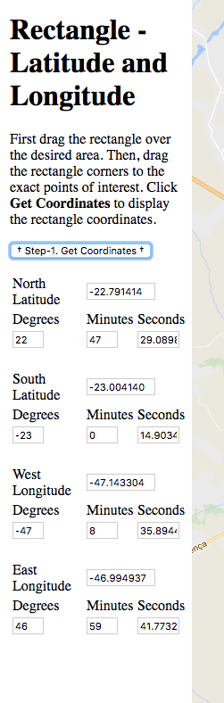

## Amostra aleatória

Agora podemos preencher a função `rgeo` com as informações de Campinas para realizar o sorteio dos locais.

```r
library(mosaic)
set.seed(XYZ)  # substitua XYZ pelos 3 ultimos digitos do RA
total_amostras = 25
amostras = rgeo(n=total_amostras, latlim = c(-23.00414,-22.791414),
                lonlim=c(-47.143304,-46.994937))
```

## Amostra aleatória

Usaremos a seguinte função para chamar o GoogleMaps centralizado na localização da amostra e com um círculo ao redor.

```r
getLocation = function(counter) {
  googleMap(amostras[counter,"lat"], amostras[counter,"lon"],
            mark=TRUE, maptype="terrain", radius=.1, browse=TRUE)
}
```

## Coleta dos dados

Você deverá então produzir uma tabela, em arquivo .csv com as seguintes colunas: "lat", "lon", "ponto" (sim ou não).

Para salvar a tabela das latitudes e longitudes em arquivo .csv:

```r
write.csv(amostras, file="dados_XXXXXXX.csv") # substitua XXXXX pelo seu RA
```

E aí você vai preenchendo este arquivo com a terceira coluna, segundo informações obtidas pelo comando `getLocation(1)`, `getLocation(2)`, etc….

## Obtendo intervalos de confiança

Como visto na aula anterior, os intervalos de \(100 (1-\alpha)\%\) de confiança para \(p\) podem então ser de duas formas:

1. Método Conservador \[IC_1(p, 1-\alpha)=\left[\hat{p}-z_{\alpha/2}\sqrt{\frac{1}{4n}};\hat{p}+z_{\alpha/2}\sqrt{\frac{1}{4n}}\right]\]
2. Usando \(\hat p\) para estimar o erro-padrão \[IC_2(p, 1-\alpha)=\left[\hat{p}-z_{\alpha/2}\sqrt{\frac{\hat{p}(1-\hat{p})}{n}};\hat{p}+z_{\alpha/2}\sqrt{\frac{\hat{p}(1-\hat{p})}{n}}\right]\]

## Resumo dos comandos

```r
library(mosaic)
set.seed(XXXXXXX)  # substitua XXXXXXX pelo RA de alguém do grupo
total_amostras1 = 10
amostras1 = rgeo(n=total_amostras1, latlim = c(-23.00414,-22.791414),
                lonlim=c(-47.143304,-46.994937))
write.csv(amostras1, file="dados_10_XXXXXXX.csv") # substitua XXXXXXX pelo RA usado no comando set.seed

getLocation = function(counter) {
  googleMap(amostras1[counter,"lat"], amostras1[counter,"lon"],
            mark=TRUE, maptype="terrain", radius=.1, browse=TRUE)
}

# para coletar os dados:
getLocation(1)
getLocation(2)
# etc...
getLocation(10)
```

## Resumo dos comandos (cont.)

```r
set.seed(XXXXXXX)  # substitua XXXXXXX pelo RA de alguém do grupo
total_amostras2 = 30
amostras2 = rgeo(n=total_amostras2, latlim = c(-23.00414,-22.791414),
                lonlim=c(-47.143304,-46.994937))
write.csv(amostras2, file="dados_30_XXXXXXX.csv") # substitua XXXXXXX pelo RA usado no comando set.seed

getLocation = function(counter) {
  googleMap(amostras2[counter,"lat"], amostras2[counter,"lon"],
            mark=TRUE, maptype="terrain", radius=.1, browse=TRUE)
}

getLocation(1)
getLocation(2)
# etc...
getLocation(30)
```

## Entregar via Moodle

- O arquivo `dados_10_XXXXXXX.csv`, substituindo XXXXX pelo RA utilizado no comando `set.seed`. O arquivo deve ter a terceira coluna preenchida com a informação: 1 caso o local tenha ponto de ônibus dentro do raio e 0, caso contrário.
- O arquivo `dados_30_XXXXXXX.csv`, substituindo XXXXX pelo RA utilizado no comando `set.seed`. O arquivo deve ter a terceira coluna preenchida com a informação: 1 caso o local tenha ponto de ônibus dentro do raio e 0, caso contrário.

(continua)

## Entregar via Moodle (cont.)

- Um arquivo .pdf com o intervalo de confiança (conservador e não conservador) de 95% para a verdadeira proporção de locais com pontos de ônibus dentro do raio especificado na área de Campinas. Mostre os cálculos intermediários até o resultado. Interprete o intervalo de confiança para este problema. Fale sobre as suposições para que o intervalo seja válido. Sua amostra satisfaz essas suposições? Discuta em detalhes. São 4 IC a serem feitos: conservador e não conservador para \(n=10\) e \(n=30\).
- Na interpretação tome cuidado ao mencionar o parâmetro da população para a qual estamos fazendo a inferência. A população de interesse era a cidade de Campinas, mas por logística, ficou sendo apenas aquela região retangular da figura apresentada.

## Resultados para \(n=10\) e \(n=30\)

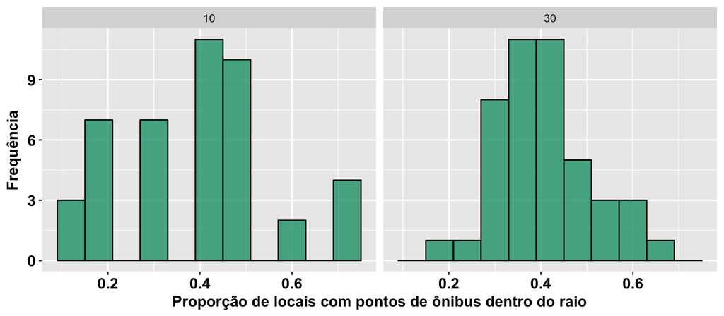

Para \(n=10\): \(\hat{p}=0.39\).

Para \(n=30\): \(\hat{p}=0.4\).

## Resultados

Usando todas as amostras de tamanho 30 da classe como se fosse uma amostra só com \(n=1320\), temos como estimativa \(\hat{p}=\frac{528}{1320}=0.4\).

\[IC_2(p, 1-\alpha)=\left[\hat{p}-z_{\alpha/2}\sqrt{\frac{\hat{p}(1-\hat{p})}{n}};\hat{p}+z_{\alpha/2}\sqrt{\frac{\hat{p}(1-\hat{p})}{n}}\right]\]

\[IC_2(p, 0.95)=\left[0.4-1.96\sqrt{\frac{0.4(1-0.4)}{1320}};0.4+1.96\sqrt{\frac{0.4(1-0.4)}{1320}}\right]\]

\[IC_2(p, 0.95)=[0.37;0.43]\]

Slides produzidos por:

- Samara Kiihl